# Covid-19 Colombia

Martin Olarte

4/28/2020

### Información sobre las Estadísticas

**Fuentes**: Johns Hopkins University, WHO, CDC, ECDC, NHC, DXY, 1point3acres, Worldometers.info, BNO, the COVID Tracking Project (para pruebas y hospitalizaciones), departamentos de salud estatales y nacionales, y reportajes de medios de comunicación locales. Más información aquí. Para información detallada de la información en Colombia se usaron los reportes diarios del [Instituto Nacional de Salud](https://www.ins.gov.co/Noticias/Paginas/Coronavirus.aspx).

- A partir del 14 de abril, los casos confirmados incluyen presuntos casos positivos y casos probables, de acuerdo con las [pautas](https://www.cdc.gov/coronavirus/2019-ncov/cases-updates/cases-in-us.html) de los Centros de Control y Prevención de Enfermedades de Estados Unidos (CDC).
- A partir del 14 de abril, los totales de muertes en los Estados Unidos incluyen confirmados y probables, de acuerdo con las [pautas](https://www.cdc.gov/coronavirus/2019-ncov/cases-updates/cases-in-us.html) de los CDC.
- Los casos recuperados fuera de China son estimaciones basadas en informes de medios de comunicación locales y en informes estatales y locales cuando están disponibles, y por lo tanto pueden ser sustancialmente más bajos que el número real.

### Gráficas Importantes

[figure not shown]

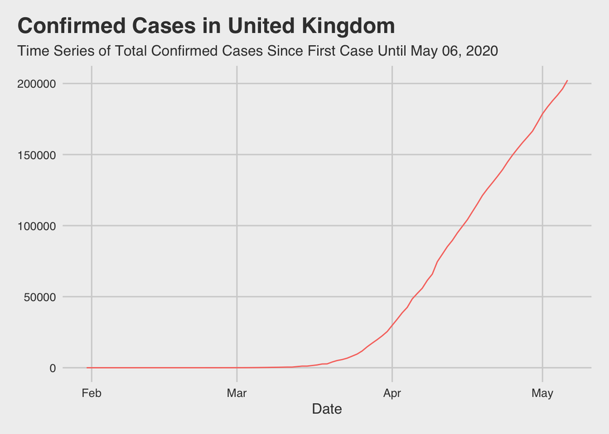

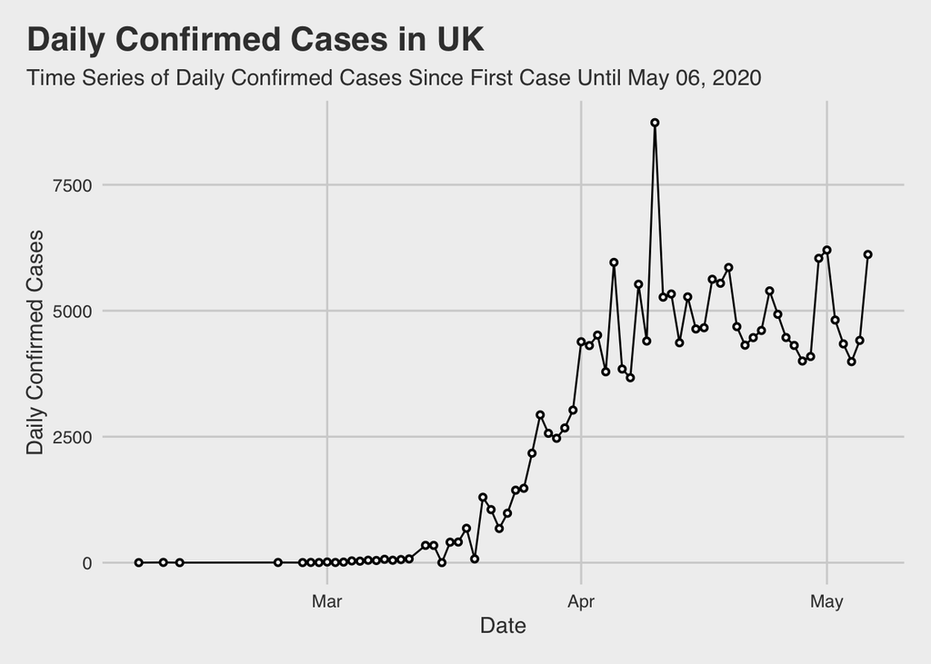

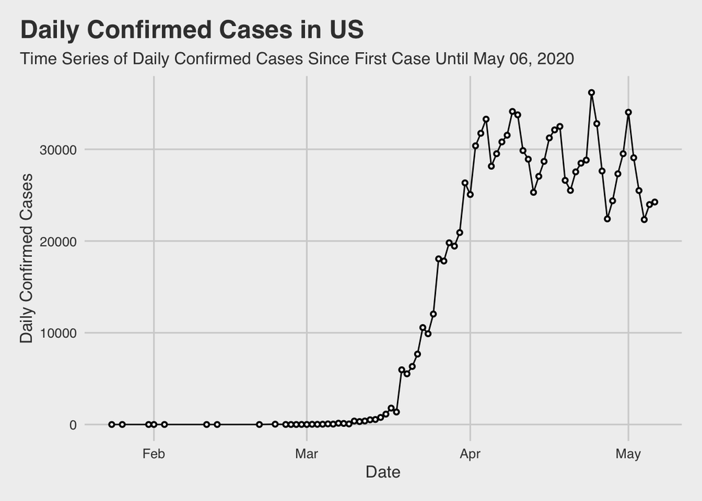

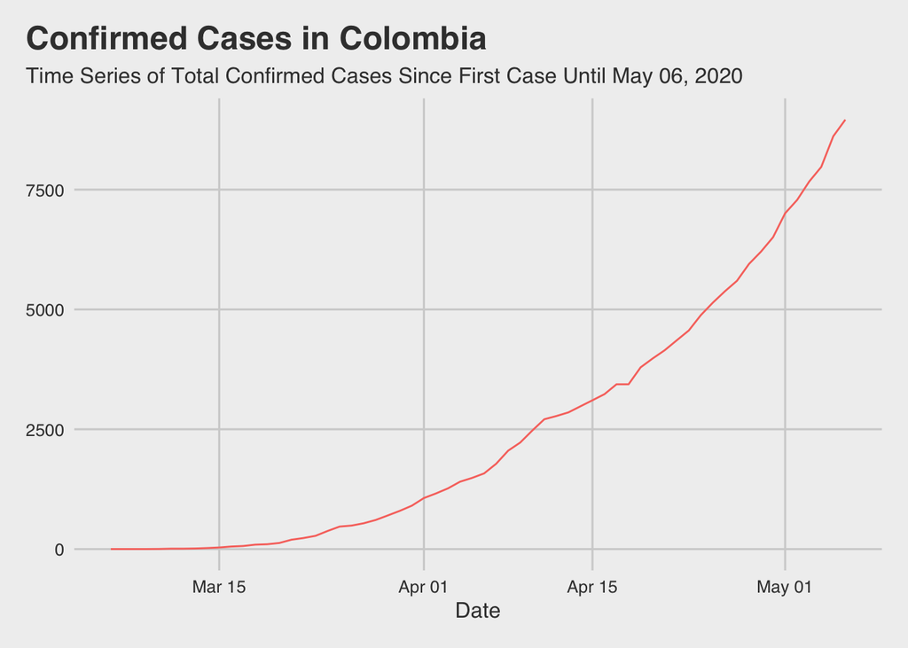

[figure not shown]

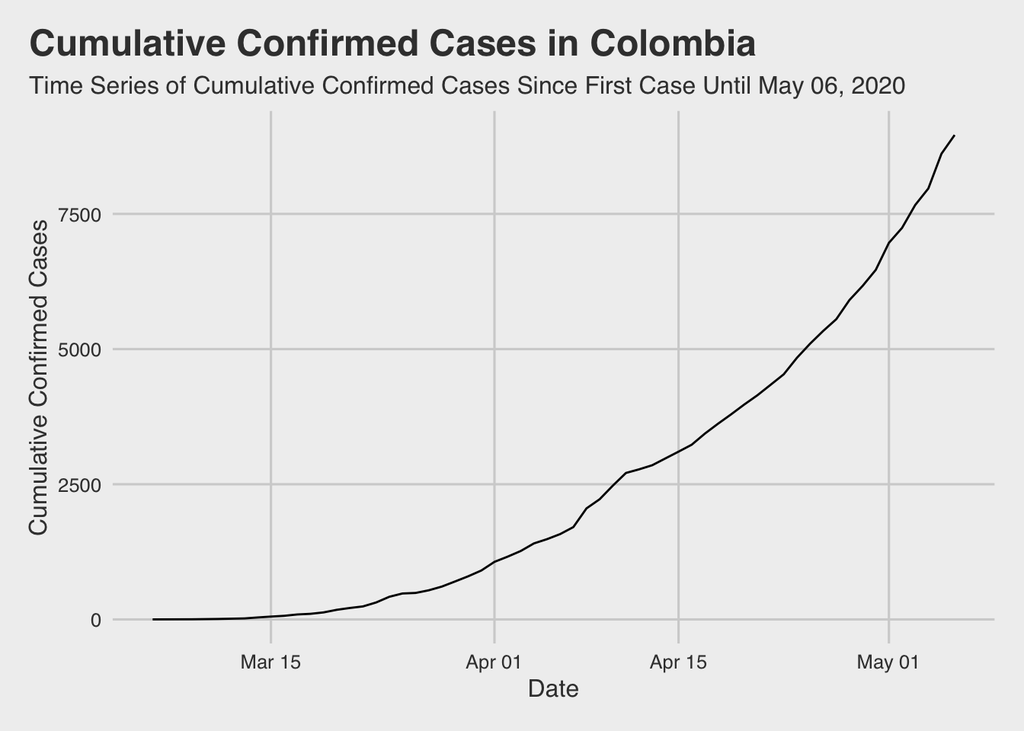

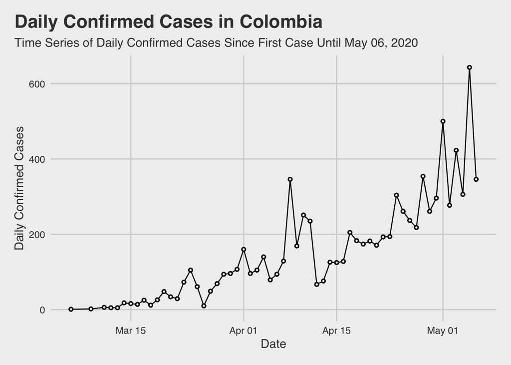

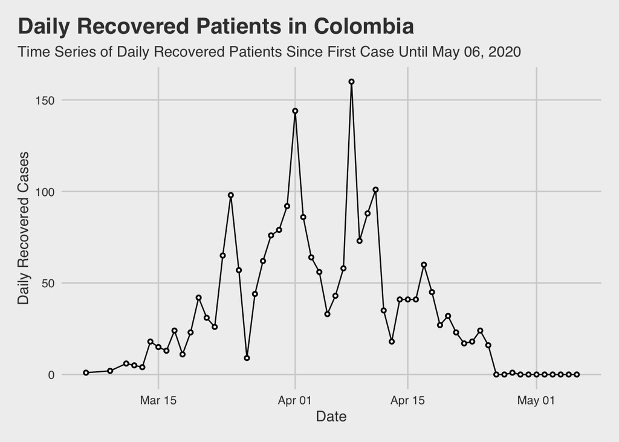

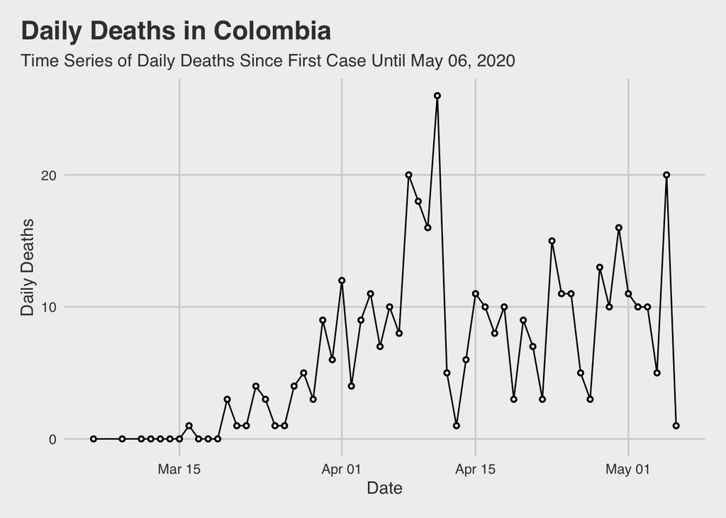

$\text{Casos Activos} = \text{Total Confirmados} - \text{Total Recuperados} - \text{Total de Muertes} =$ **6414**

$\text{Tasa de Incidencia} = \frac{\text{Total Confirmados}}{1.000.000 \text{ de habitantes}} =$ **178**

$\text{Tasa de Letalidad de Casos Confirmados (%)} = \frac{\text{Número de muertes registradas}}{\text{ Número de casos confirmados}}\times 100 =$ **4.43**

$\text{Muestras Procesadas por Millon de Habitantes} = \frac{\text{Número de muestras procesadas}}{1.000.000 \text{ de habitantes}} =$ **2603**